# Personalized Drug Repositioning for IBD

Samuel Finlayson

8/23/2018

## Differential Expression

We begin by conducting a **differential expression analysis** (not shown in full, but can be found [here](https://amp.pharm.mssm.edu/biojupies/notebook/7kSVEyB73)) that compares gene expression measurements from affected vs unaffected components of the patient’s gastrointestinal tract.

By focusing on *functional genomics*, who hope to focus on the key differences in the behavior of cells that are flaring up and cells that are functioning normally. This differential expression analysis produces a number for each gene in the genome, which taken together forms a **signature** of the disease:

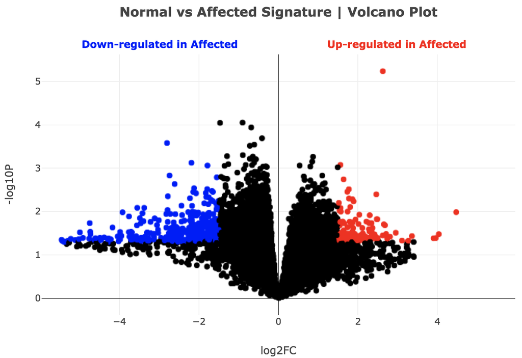

## L1000FWD Similarity Scores

The Ma’ayan Lab has released a dataset, the L1000FWD, in which they have computed gene expression signatures based on differential expression analysis before and after *perturbation* by each of some 16,000 small molecules (drugs).

In order to try to find what treatment might be useful, we compute the **cosine similarity** between the patient’s *disease signature* and the *drug signature* for each of the thousands of drugs. The result is a score between -1 and 1 for each drug, with -1 corresponding to a perfectly opposite signature and +1 corresponding to a perfectly aligned signature. Since we are looking for drugs to *reverse* the disease, we are trying to find drug signatures whose cosine similarity to the disease signature are as negative as possible.

The following plot shows the distribution of similarity scores over every drug in the dataset, along with some summary statistics:

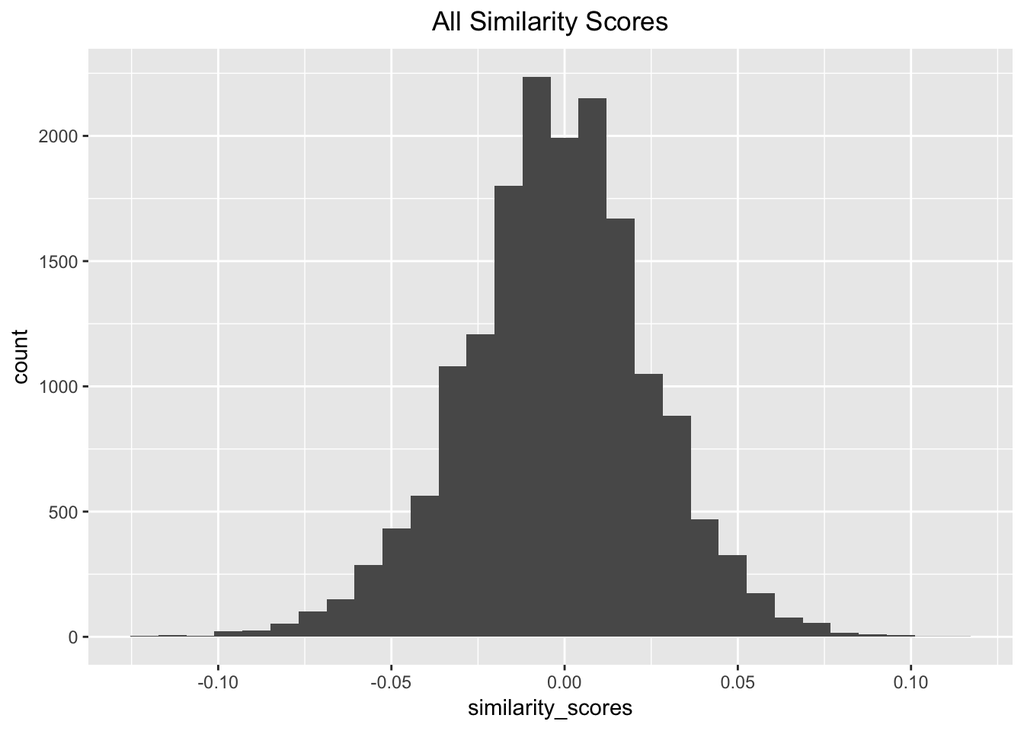

If you prefer numbers, here is a table summarising the same data:

| Min. | 1st Qu. | Median | Mean | 3rd Qu. | Max. |
| --- | --- | --- | --- | --- | --- |
| -0.1237 | -0.02014 | -0.001439 | -0.002571 | 0.01439 | 0.1108 |

## Adding confidence using the L1000CDS Similarity Scores

To refine our search, we will employ the **L1000CDS** dataset, which is a slightly older version of the same idea they implemented in the L1000FWD dataset. Since we want our findings to be as robust as possible, I will subset the L1000FWD results shown above to include only those drugs that also show up in the top 50 “best” drugs from the L1000CDS dataset.

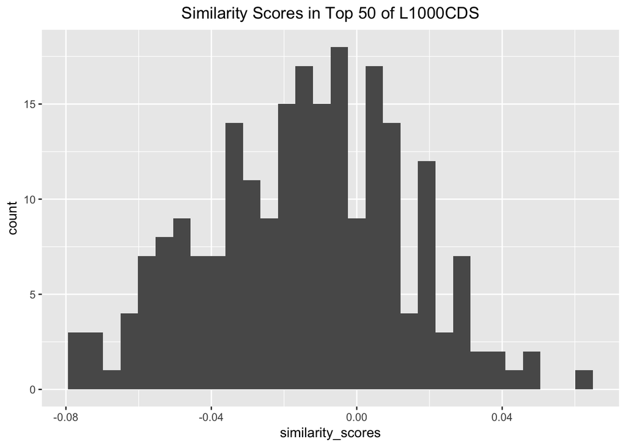

| Min. | 1st Qu. | Median | Mean | 3rd Qu. | Max. |
| --- | --- | --- | --- | --- | --- |
| -0.07914 | -0.03309 | -0.01295 | -0.01478 | 0.005396 | 0.06043 |

## Taking a closer look at the results

There are 11 such drugs. Each is represented in the L1000FWD dataset many times, because they have been applied to a range of cell lines and for different durations. Here are summary states for the signature similarity scores for each drug:

| drug | Mean | Min | Max | Count |
| --- | --- | --- | --- | --- |
| gemcitabine | -0.0226619 | -0.0748201 | 0.0115108 | 16 |
| parthenolide | -0.0210248 | -0.0791367 | 0.0273381 | 49 |
| amsacrine | -0.0197122 | -0.0633094 | 0.0446043 | 20 |
| phorbol-12-myristate-13-acetate | -0.0191847 | -0.0676259 | 0.0158273 | 18 |
| importazole | -0.0179477 | -0.0446043 | 0.0143885 | 19 |
| etoposide | -0.0149186 | -0.0791367 | 0.0302158 | 19 |
| isoliquiritigenin | -0.0136267 | -0.0618705 | 0.0474820 | 17 |
| chlorambucil | -0.0133094 | -0.0604317 | 0.0287770 | 12 |
| piperlongumine | -0.0036771 | -0.0589928 | 0.0374101 | 18 |
| ldn-193189 | -0.0022006 | -0.0345324 | 0.0374101 | 17 |
| saracatinib | -0.0016928 | -0.0546763 | 0.0604317 | 17 |

Most of these results are fairly big-gun chemotherapy agents. Filtering these out, we’re left with three compounds:

- **Parthenolide** is an extract from the feverfew plant, which has been used in herbalism for a variety of ailments
- **Isoliquiritigenin** is a natural flavonoid extracted from licorice. It isn’t extremely well understood yet, but it has been preclinically tested with promising uses in several cancers and in osteoarthiritis. It is a sirtuin activator, which some believe promotes longevity
- **Piperlongumine** is an extract from the Long Pepper, which has been used traditionally in Southeast Asia as an anti-inflammatory agent. It’s also been investigated as a anti-neoplastic drug

### Parthenolide

[Feverfew/parthenolide](https://www.ncbi.nlm.nih.gov/pmc/articles/PMC3210009/) has shown a lot of anti-inflammatory properties, which is promising. I also like the fact that it appears to be very safe, and has been taken orally by many people, particularly for migraines. (One thing to keep in mind, however, is that you’re recommended against taking it right before surgery since it slows down platelets).

I don’t see much literature pointing directly to its use in inflammatory bowel disease (other than to prevent or treat colon cancer in the setting of colitis), but there is at least one study suggesting it as a successful treatment for [colitis in mice](https://www.ncbi.nlm.nih.gov/pubmed/22155740), and it is known to work in part by inhibiting NF-kappa beta and IKKβ, which are definitely known to play a [huge role in IBD](https://www.ncbi.nlm.nih.gov/pubmed/18479258).

#### Signatures

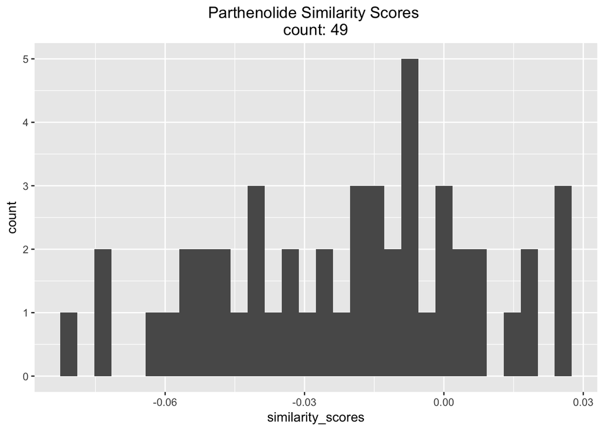

| Min. | 1st Qu. | Median | Mean | 3rd Qu. | Max. |
| --- | --- | --- | --- | --- | --- |
| -0.07914 | -0.04029 | -0.01727 | -0.02102 | -0.001439 | 0.02734 |

### Isoliquiritigenin

Isoliquiriteginin is a licorice extract that has also been used as an anti-inflammatory herbal remedy for thousands of years. Several papers has shown it as potentially effective for [treating IBD in mice](https://www.nature.com/articles/srep14046/figures/4), perhaps including through the [MAPK pathway](https://scinapse.io/papers/2228474836), by improving [the microbiome](https://www.ncbi.nlm.nih.gov/pmc/articles/PMC5356739/), or by [inhibiting TNF-α](https://www.ncbi.nlm.nih.gov/pubmed/28012970).

#### Signatures

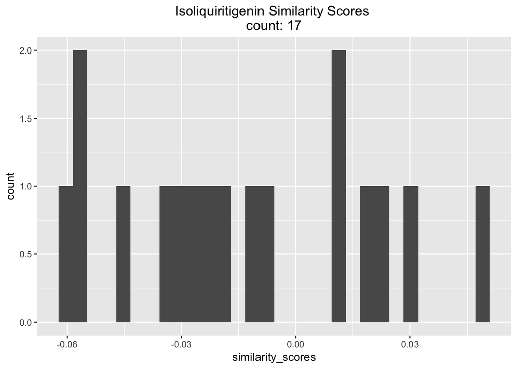

| Min. | 1st Qu. | Median | Mean | 3rd Qu. | Max. |
| --- | --- | --- | --- | --- | --- |
| -0.06187 | -0.03453 | -0.01727 | -0.01363 | 0.01007 | 0.04748 |

### Piperlongumine

The long pepper and its derivatives have also been extensively used as anti-inflammatory agents for many years. Piperlongumine is one of its extracts, and is thought to exert anti-inflammatory effects through many of the same pathways as above, including [NF-kappa beta and MAPK](https://www.ncbi.nlm.nih.gov/pubmed/25850000), which play roles in IBD. Piperine (an extract from the same pepper) has also been directly studied in IBD models and [shown promise](https://www.ncbi.nlm.nih.gov/pubmed/25907981). Some home remedy-style websites also include long pepper as [part of a remedy for UC](http://www.thebrightpost.com/ayurveda-ulcerative-colitis.html).

#### Signatures

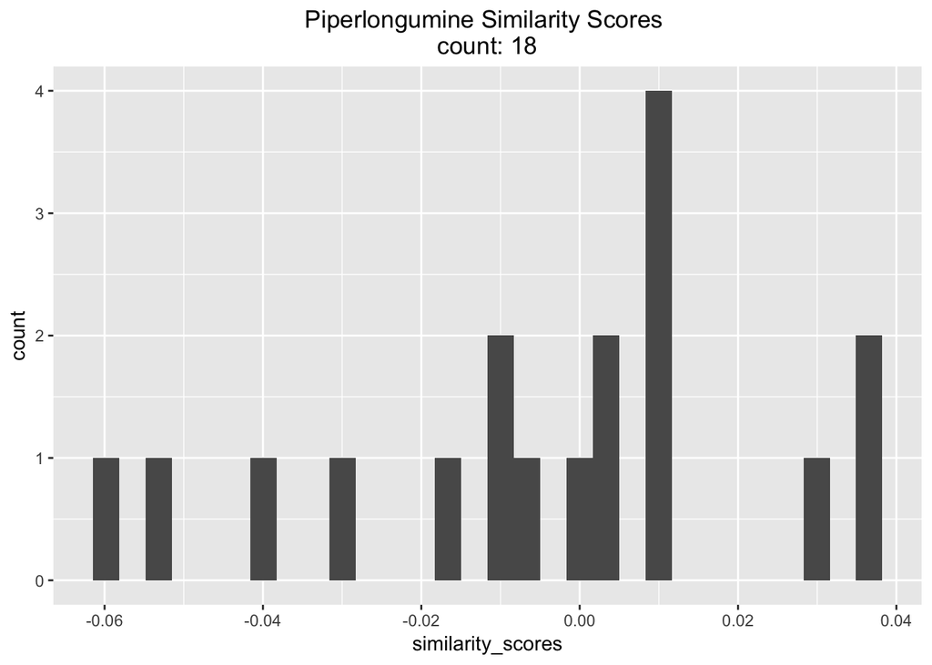

| Min. | 1st Qu. | Median | Mean | 3rd Qu. | Max. |
| --- | --- | --- | --- | --- | --- |
| -0.05899 | -0.01475 | 0.002878 | -0.003677 | 0.01151 | 0.03741 |